# Machine Learning Types and Algorithms

Use case machine learning with R

Cevi Herdian, B. Sc

30.01.2019

**Note:**

-An R Notebook is an R Markdown document with chunks that can be executed independently and interactively, with output visible immediately beneath the input.

-Notebook output are available as HTML, PDF, Word, or Latex.

-This Notebook as HTML is preferably open with Google Chrome.

-R-Code can be extracted as Rmd file under the button “Code” in the notebook.

-This Notebook using iterative development. It means the process starts with a simple implementation of a small set of idea requirements and iteratively enhances the evolving versions until the complete version is implemented and perfect.

# Common terms

**1. Labelled data:**

A set of data, an example would be all the prices of the house based on size.

**2. Classification:**

Separating dataset into groups (luxury, premium, medium, cheap).

**3. Regression:**

Estimation of the price of the house based on size (univariate regression).

**4. Association:**

Discovering interesting relations between variables in large databases where the connection found is crucial.

# 4 types of machine earning

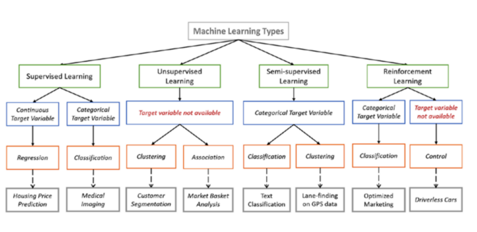

```r
#https://towardsdatascience.com/machine-learning-types-and-algorithms-d8b79545a6ec
```

**1. Supervised Learning:**

“The outcome or output for the given input is known before itself”.

Just like a human child is shown a car and told so, when it sees a completely different car among others still identifies it as a car, the same method is employed here.

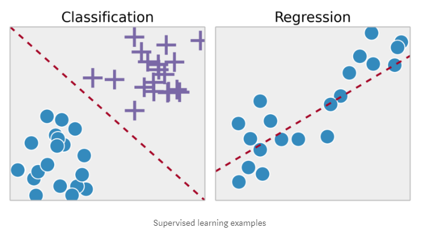

```r
#https://towardsdatascience.com/machine-learning-types-and-algorithms-d8b79545a6ec
```

> Key points:
- Regression and classification problems are mainly solved here.
- Labelled data is used for training here.
- Popular Algorithms: Linear Regression, Support Vector Machines (SVM), Neural Networks, Decision Trees, * Naive Bayes, Nearest Neighbor.
- It is mainly used in Predicting Modelling.

**2. Unsupervised Learning:**

“The outcome or output for the given inputs is unknown”

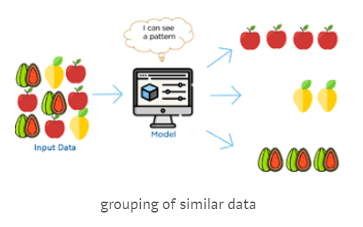

```r
#https://towardsdatascience.com/machine-learning-types-and-algorithms-d8b79545a6ec
```

> Key points:
- It is used for Clustering problems(grouping), Anomaly Detection (in banks for unusual transactions) where there is a need for finding relationships among the data given.
- Unlabeled data is used in unsupervised learning.
- Popular Algorithms: k-means clustering, Association rule.
- It is mainly used in Descriptive Modelling.

**3. Semi-supervised Learning:**

- Between that of Supervised and Unsupervised Learning
- The most important in real-world scenarios: labelled and unlabeled data

**4. Reinforced Learning:**

The trial and error method. The machine learns from past experience and tries to capture the best possible knowledge to make accurate decisions based on the feedback received.

“The outcome or output for the given inputs is unknown”

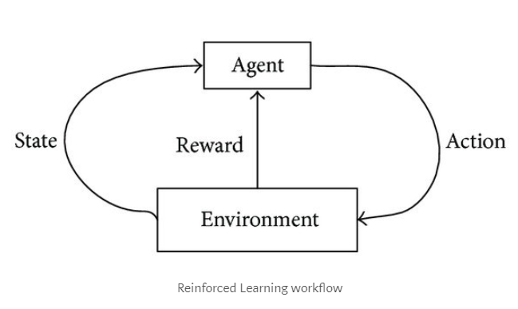

```r
#https://towardsdatascience.com/machine-learning-types-and-algorithms-d8b79545a6ec
```

> Key points:
- Modelled as Markov Decision Process
- The most popular algorithms used here is Q-Learning, Deep Adversarial Networks
- Its practical applications include computer playing board games such as chess and GO, Self-driving cars etc

# Change log update

- 02.02.2019

# References

- https://towardsdatascience.com/machine-learning-types-and-algorithms-d8b79545a6ec

# License

MIT